# Part 2AB

ENMIN LI

## Part ii: Regression - iiA)

## Load packages

```r
library(dplyr)
```

```r
library(ggplot2)
library(rstanarm)
library(bayesplot)
theme_set(bayesplot::theme_default())
```

## Read data

```r
df_all <- readr::read_csv("final_project_train.csv", col_names = TRUE)
```

## Before using advanced methods, you need to develop a baseline understanding of the log transformed response as a function of the inputs using linear modeling techniques.

```r
dfii <- df_all %>% mutate(y = log(response))
print(dfii)
```

```
## # A tibble: 677 × 39
##    rowid region customer xb_01 xb_02 xb_03 xn_01 xn_02 xn_03 xa_01 xa_02 xa_03
##    <dbl> <chr>  <chr>    <dbl> <dbl> <dbl> <dbl> <dbl> <dbl> <dbl> <dbl> <dbl>
##  1     1 XX     B         4        4     4 3         3     3 12       12    12
##  2     3 XX     B         1        1     1 2         2     2  3        3     3
##  3     4 XX     B         2        2     2 2         4     0  9        9     9
##  4     5 XX     B         2.52    11    -6 1.53      9    -3  7.08    29    -7
##  5     8 XX     B         2.55     6    -1 0.839     3    -4  6.45    17    -2
##  6     9 XX     B         3.07     6     1 1.86      8    -2  6.86    18     2
##  7    11 XX     B         3.09    10    -4 1.51      6    -5  7.66    24    -9
##  8    14 XX     B         3.71    12    -4 1.59     10    -6  8.16    27    -5
##  9    15 XX     B         2.70     9    -2 1.17     10    -3  6.89    20    -3
## 10    16 XX     B         2.82    10    -4 1.02      4    -5  7.14    19    -3
## # … with 667 more rows, and 27 more variables: xb_04 <dbl>, xb_05 <dbl>,
## #   xb_06 <dbl>, xb_07 <dbl>, xb_08 <dbl>, xn_04 <dbl>, xn_05 <dbl>,
## #   xn_06 <dbl>, xn_07 <dbl>, xn_08 <dbl>, xa_04 <dbl>, xa_05 <dbl>,
## #   xa_06 <dbl>, xa_07 <dbl>, xa_08 <dbl>, xw_01 <dbl>, xw_02 <dbl>,
## #   xw_03 <dbl>, xs_01 <dbl>, xs_02 <dbl>, xs_03 <dbl>, xs_04 <dbl>,
## #   xs_05 <dbl>, xs_06 <dbl>, response <dbl>, outcome <chr>, y <dbl>
```

## Use lm to fit the following linear models:

### Categorical variables only - linear additive

```r
mod1 <- lm(y ~ region + customer, data = dfii)
```

### Continuous variables only - linear additive

```r
mod2 <- lm(y ~ ., data = dfii %>% select(starts_with("x"), y))
```

### All categorical and continuous variables - linear additive

```r
mod3 <- lm(y ~ ., data = dfii %>% select(!c( "response", "outcome")))
```

### Interact region with continuous inputs, do not include customer

```r
mod4 <- lm(y ~ region * (.-region), data = dfii %>% select(!c("customer", "response", "outcome")))
```

### Interact customer with continuous inputs, do not include region

```r
mod5 <- lm(y ~ customer * (.-customer), data = dfii %>% select(!c("region", "response", "outcome")))
```

### All pairwise interactions of continuous inputs, do not include categorical inputs

```r
mod6 <- lm(y ~ (.)^2, data = dfii %>% select(starts_with("x"), y))
```

### 3 models with basis functions of your choice

```r
dfii <- df_all %>%
  mutate(y = log(response)) %>%
  select(region,customer,y)
mod7 <- lm(y~.^2, data = dfii)
```

```r
dfii <- df_all %>%
  mutate(y = log(response)) %>%
  select(starts_with('xs'),y)
mod8 <- lm(y~.^2, data = dfii)
```

```r
dfii <- df_all %>%
  mutate(y = log(response)) %>%
  select(region,customer,y)
mod9 <- lm(y ~ customer*region, data = dfii)
```

## Which of the 9 models is the best? What performance metric did you use to make your selection?

```r
extract_metrics <- function(my_mod, mod_name)
{
  broom::glance(my_mod) %>%
    mutate(model_name = mod_name)
}

all_model_metrics <- purrr::map2_dfr(list(mod1,
                                          mod2,
                                          mod3,
                                          mod4,
                                          mod5,
                                          mod6,
                                          mod7,
                                          mod8,
                                          mod9),
                                     c("mod1",
                                       "mod2",
                                       "mod3",
                                       "mod4",
                                       "mod5",
                                       "mod6",
                                       "mod7",
                                       "mod8",
                                       "mod9"),
                                     extract_metrics)
```

```r
all_model_metrics %>%
  dplyr::select(model_name, BIC, AIC) %>%
  mutate(SUM_AIC_BIC = AIC + BIC)
```

```
## # A tibble: 9 × 4
##   model_name   BIC   AIC SUM_AIC_BIC
##   <chr>      <dbl> <dbl>       <dbl>
## 1 mod1       1015.  961.       1976.
## 2 mod2        772.  614.       1386.
## 3 mod3        613.  405.       1018.
## 4 mod4        876.  397.       1274.
## 5 mod5       1898.  503.       2401.
## 6 mod6       2994.  451.       3445.
## 7 mod7       1019.  947.       1966.
## 8 mod8       1184. 1080.       2264.
## 9 mod9       1019.  947.       1966.
```

The model with all categorical and continuous variables - linear additive is the best of the 9 models.

## Visualize the coefficient summaries for your top 3 models.

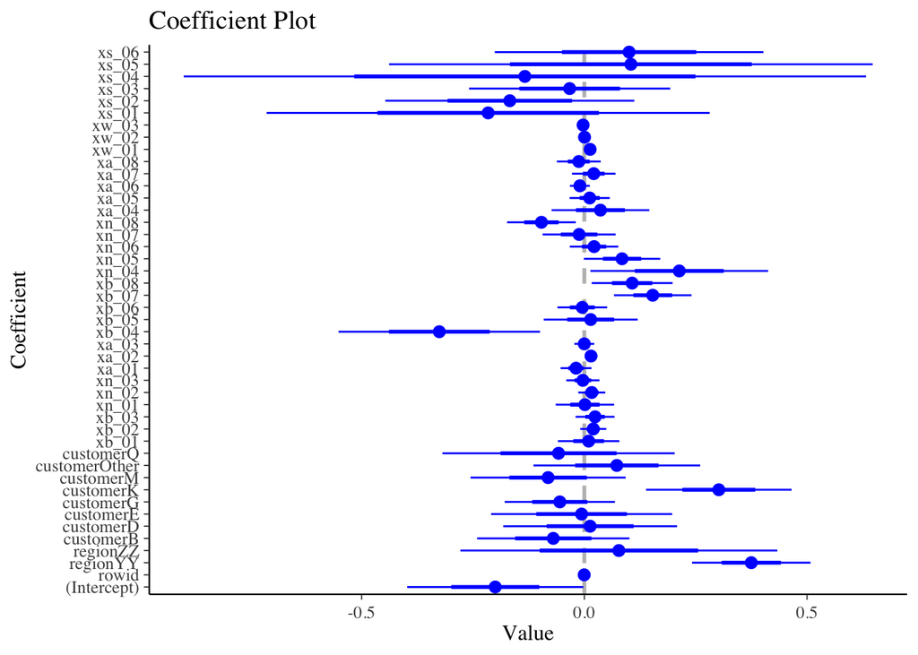

```r
mod3%>% coefplot::coefplot()
```

[figure not shown]

```r
mod4 %>% coefplot::coefplot()
```

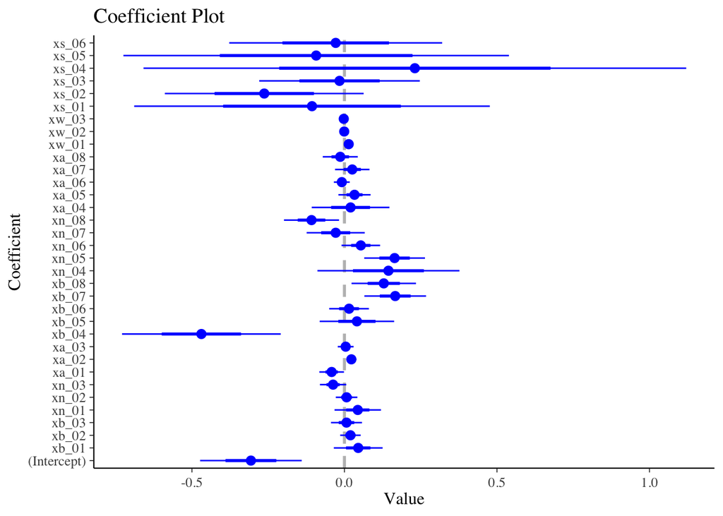

```r
mod2 %>% coefplot::coefplot()
```

## How do the coefficient summaries compare between the top 3?

TOP3 best model is mod3,mod4,mod2.

1st model, “region”, “customer”, “xb_04”, “xb_07”, “xb_08”, “xn_04”, “xn_08” and “xw_01” aresignificant; 2nd model, “xn_04” is significant; 3rd model, “xb_04”, “xb_07”, “xb_08”, “xn_05”, “xn_08” and “xw_01” are statistically significant.

## Which inputs seem important?

“xb_04”, “xb_07”, “xb_08”, “xn_08” and “xw_01” which seem like important.

##PART II-B ## Fit 2 Bayesian linear models one must be the best and second model.

```r
dfii <- df_all %>% mutate(y = log(response))
print(dfii)
```

```
## # A tibble: 677 × 39
##    rowid region customer xb_01 xb_02 xb_03 xn_01 xn_02 xn_03 xa_01 xa_02 xa_03
##    <dbl> <chr>  <chr>    <dbl> <dbl> <dbl> <dbl> <dbl> <dbl> <dbl> <dbl> <dbl>
##  1     1 XX     B         4        4     4 3         3     3 12       12    12
##  2     3 XX     B         1        1     1 2         2     2  3        3     3
##  3     4 XX     B         2        2     2 2         4     0  9        9     9
##  4     5 XX     B         2.52    11    -6 1.53      9    -3  7.08    29    -7
##  5     8 XX     B         2.55     6    -1 0.839     3    -4  6.45    17    -2
##  6     9 XX     B         3.07     6     1 1.86      8    -2  6.86    18     2
##  7    11 XX     B         3.09    10    -4 1.51      6    -5  7.66    24    -9
##  8    14 XX     B         3.71    12    -4 1.59     10    -6  8.16    27    -5
##  9    15 XX     B         2.70     9    -2 1.17     10    -3  6.89    20    -3
## 10    16 XX     B         2.82    10    -4 1.02      4    -5  7.14    19    -3
## # … with 667 more rows, and 27 more variables: xb_04 <dbl>, xb_05 <dbl>,
## #   xb_06 <dbl>, xb_07 <dbl>, xb_08 <dbl>, xn_04 <dbl>, xn_05 <dbl>,
## #   xn_06 <dbl>, xn_07 <dbl>, xn_08 <dbl>, xa_04 <dbl>, xa_05 <dbl>,
## #   xa_06 <dbl>, xa_07 <dbl>, xa_08 <dbl>, xw_01 <dbl>, xw_02 <dbl>,
## #   xw_03 <dbl>, xs_01 <dbl>, xs_02 <dbl>, xs_03 <dbl>, xs_04 <dbl>,
## #   xs_05 <dbl>, xs_06 <dbl>, response <dbl>, outcome <chr>, y <dbl>
```

```r
bayes_mod3 <- stan_lm(y ~ (.-region-customer)*(region), data = dfii,
                                        prior = R2(location = 0.5),
                                        seed = 2002)
bayes_mod4 <- stan_lm(y ~ (.), data = dfii,
                                      prior = R2(location = 0.5),
                                      seed = 2002)
```

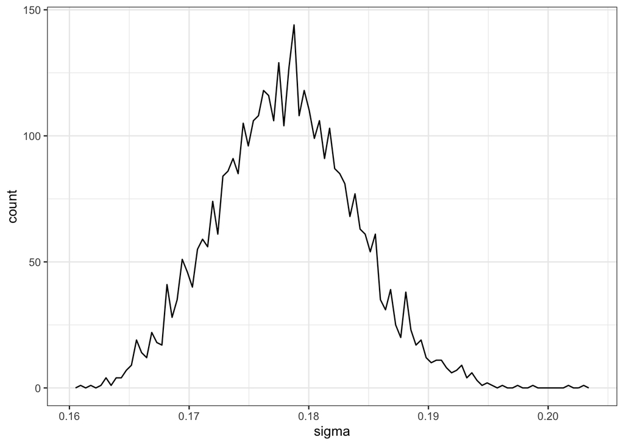

```r
as.data.frame(bayes_mod3) %>% tibble::as_tibble() %>%
                    select(sigma) %>%
  ggplot(mapping = aes(x = sigma)) +
  geom_freqpoly(bins = 100)+
  theme_bw()
```

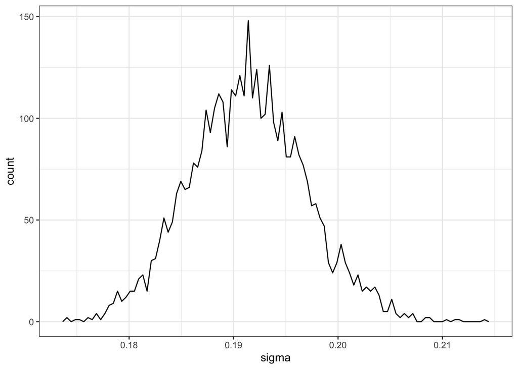

```r
as.data.frame(bayes_mod4) %>% tibble::as_tibble() %>%
                    select(sigma) %>%
  ggplot(mapping = aes(x = sigma)) +
  geom_freqpoly(bins =100)+
  theme_bw()
```